**Stat 230: Linear Models**  
**Homework 3**  
**Professor Ding**  
**Lev Golod**

#### Question 6, part A

```r
## Input the data
load('./data/Carseats.RData')
car <- Carseats
rm(Carseats)
names(car) <- tolower(names(car))
fit1 <- lm(sales ~ price + urban + us, car)
summary(fit1)
```

```
##
## Call:
## lm(formula = sales ~ price + urban + us, data = car)
##
## Residuals:
##     Min      1Q  Median      3Q     Max
## -6.9206 -1.6220 -0.0564  1.5786  7.0581
##
## Coefficients:
##              Estimate Std. Error t value Pr(>|t|)
## (Intercept) 13.043469   0.651012  20.036  < 2e-16 ***
## price       -0.054459   0.005242 -10.389  < 2e-16 ***
## urbanYes    -0.021916   0.271650  -0.081    0.936
## usYes        1.200573   0.259042   4.635 4.86e-06 ***
## ---
## Signif. codes:  0 '***' 0.001 '**' 0.01 '*' 0.05 '.' 0.1 ' ' 1
##
## Residual standard error: 2.472 on 396 degrees of freedom
## Multiple R-squared:  0.2393, Adjusted R-squared:  0.2335
## F-statistic: 41.52 on 3 and 396 DF,  p-value: < 2.2e-16
```

#### Question 6, part B

Interpret the coefficients:

*Price:* ceteris paribus, a one-unit increase in price is predicted to be  
associated with a -0.055 unit change in sales. This relationship is significant.

*Urban:* ceteris paribus, those observations in the ‘yes’ category are predicted  
to differ in sales from the ‘no’ category by -0.022 units. This relationship is  
not significant.

*US* ceteris paribus, those observations in the ‘yes’ category are predicted  
to differ in sales from the ‘no’ category by 1.20 units. This relationship is  
significant.

#### Question 6, part C

The regression model is $\hat y_i = \hat \beta_0 + \hat \beta_1\ x_{1,i} + \hat \beta_2\ x_{2,i} + \hat \beta_3\ x_{3,i}$,  
where $\hat \beta_0 = 13.043469$, $\hat \beta_1 = -0.054459$, $\hat \beta_2 = -0.021916$,  
$\hat \beta_3 = 1.200573$, $\hat y_i$ is the predicted Sales for observation i,  
$x_{1,i}$ is the Price of observation i, $x_{2,i}$ is 1 if the ‘Urban’ value  
of observation i is ‘Yes’, and 0 otherwise, $x_{3,i}$ is 1 if the ‘US’ value  
of observation i is ‘Yes’, and 0 otherwise.

#### Question 6, part D

At the level of $\alpha = 0.05$ we reject the Null Hypothesis $\beta_j = 0$ for  
$\beta_1$ and $\beta_3$, that is, Price and US.

#### Question 6, part E

```r
fit2 <- lm(sales ~ price + us, car)
summary(fit2)
```

```
##
## Call:
## lm(formula = sales ~ price + us, data = car)
##
## Residuals:
##     Min      1Q  Median      3Q     Max
## -6.9269 -1.6286 -0.0574  1.5766  7.0515
##
## Coefficients:
##             Estimate Std. Error t value Pr(>|t|)
## (Intercept) 13.03079    0.63098  20.652  < 2e-16 ***
## price       -0.05448    0.00523 -10.416  < 2e-16 ***
## usYes        1.19964    0.25846   4.641 4.71e-06 ***
## ---
## Signif. codes:  0 '***' 0.001 '**' 0.01 '*' 0.05 '.' 0.1 ' ' 1
##
## Residual standard error: 2.469 on 397 degrees of freedom
## Multiple R-squared:  0.2393, Adjusted R-squared:  0.2354
## F-statistic: 62.43 on 2 and 397 DF,  p-value: < 2.2e-16
```

As the summary output for the model indicates, the p value associated with  
the F statistic is small. We reject the Null Hypothesis $\beta_1 = \beta_2 = 0$.  
We conclude that this model does have some explanatory power over $Y$, compared  
to simply predicting $Y$ by a constant $\beta_0$.

#### Question 6, part F

The models in E and F both have an adjusted R-squared around 0.23. This indicates  
a somewhat weak fit. There is a substantial amount of variability in $Y$ that  
is not captured in these models.

#### Question 6, part G

We can use the Student’s t distribution to construct confidence intervals  
for the regression coefficients. The df for the t dist is n-j where j is the  
number of parameters estimated by the model, including intercept. In this case  
j = 3.

```r
n = nrow(car)
j = 3
alpha = 0.05
a <- summary(fit2)$coefficients
coeffs <- list(b0 = a[1,1:2], b1 = a[2,1:2], b2 = a[3,1:2])
myfun <- function(x) x[1] + c(-1,1) * x[2] *
  qt(alpha/2, df = n-j, lower.tail = FALSE)
lapply(coeffs, myfun)
```

```
## $b0
## [1] 11.79032 14.27127
##
## $b1
## [1] -0.06475984 -0.04419543
##
## $b2
## [1] 0.6915196 1.7077663
```

#### Question 6, part H

I will define a leverage point as any point whose leverage $h_{ii} > 3 \frac{p}{n}$,  
where $h_{ii}$ is a diagonal entry in the Hat Matrix, and $p$ is the number of  
parameters estimated by the model (including the coefficient), in our case 3.

```r
## Calculate the hat matrix for leverage purposes
# grab the predictors we used
X <- car[, c('price', 'us')]
X$us <- as.numeric(X$us) - 1
# add that trusty column of ones
X <- cbind(1, X)
X <- as.matrix(X)
n <- nrow(X)

H = X %*% solve(t(X) %*% X) %*% t(X)
Hii = diag(H)
names(Hii) <- 1:n
numlev <- sum(Hii > 3*sum(Hii)/n)
sprintf("There are %s leverage points, based on large leverage scores h[i,i]",
        numlev)
```

```
## [1] "There are 6 leverage points, based on large leverage scores h[i,i]"
```

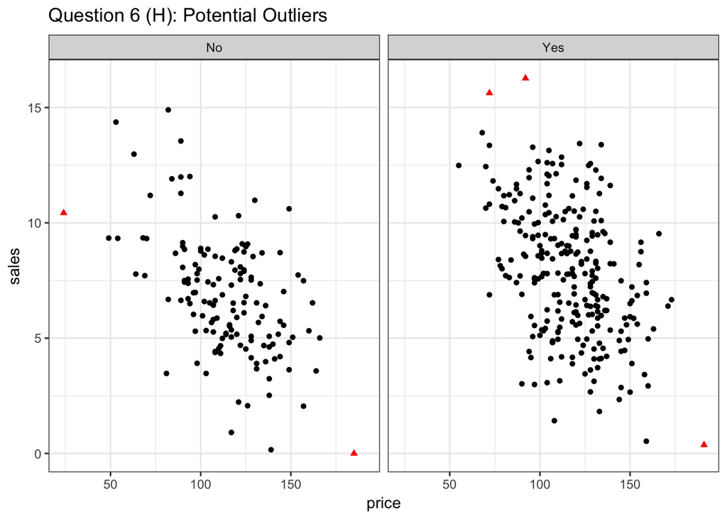

```r
## Plot to identify potential outliers
car$out = car$price < 45 | car$price > 175 | car$sales > 15

plot1 <- ggplot(car, aes(x=price, y=sales, shape = out, colour = out)) +
  geom_point() +
  facet_grid(. ~ us) +
  scale_colour_manual(values=c("black", "red")) +
  ggtitle("Question 6 (H): Potential Outliers") +
  theme_bw() +
  theme(legend.position="none")
plot1
```

The points marked as red triangles are somewhat far away from the general mass of  
other points. I regard them as potential outliers.

I conclude that we have some evidence of both outliers and high-leverage points.